# Assignment3

Sricharraan Ramaswamy

02/02/2022

```r
library(reshape)
library(ggplot2)
```

```r
load("lattice.Rdata")
head(food.web)
```

```
##   mean.length dimension
## 1        3.13     Mixed
## 2        2.71     Mixed
## 3        2.30       Two
## 4        2.74     Mixed
## 5        2.00     Mixed
## 6        3.82     Mixed
```

## Question 1

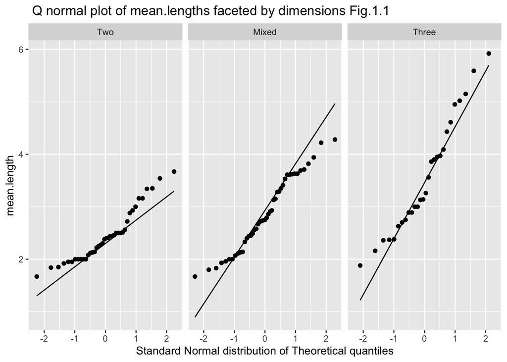

```r
ggplot(food.web, aes(sample = mean.length)) + stat_qq() + stat_qq_line() + facet_wrap(~dimension, ncol = 3) + ggtitle(" Q normal plot of mean.lengths faceted by dimensions Fig.1.1 ") + xlab("Standard Normal distribution of Theoretical quantiles") + ylab("mean.length")
```

Detailed Analysis of each dimension graph,

1. Dimension Two - Between mean.length 2 and 2.75 we can clearly see the points lie on the normal line rest data points nowhere lies on the normal line
2. Dimension Mixed - The plot is almost same as the plot of dimension two as we can see that in the middle sector the data points is normally distributed
3. Dimension Three - Compared to dimension two adn mixed the data points are less in dimesion three and is better normally distributed than dimension two and mixed

Overall we can say that because of the skweness the spread of the graph is moderate

## Question 2

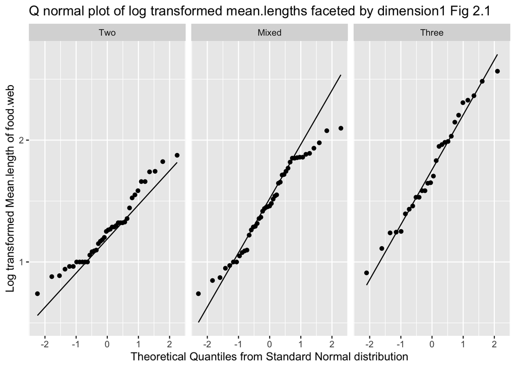

```r
ggplot(food.web,aes(sample=log2(mean.length))) + stat_qq() + stat_qq_line() +facet_wrap(~dimension) +
  ggtitle("Q normal plot of log transformed mean.lengths faceted by dimension1 Fig 2.1") + xlab("Theoretical Quantiles from Standard Normal distribution") +ylab("Log transformed Mean.length of food.web")
```

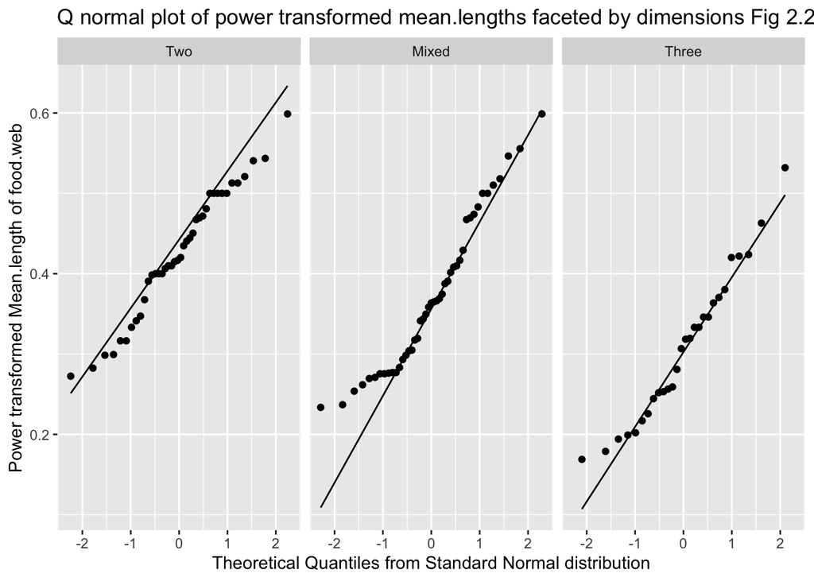

```r
food.web$inv.mean.length = food.web$mean.length ^ (-1)
ggplot(food.web,aes(sample=inv.mean.length)) + stat_qq() + stat_qq_line() +facet_wrap(~dimension) + ggtitle("Q normal plot of power transformed mean.lengths faceted by dimensions Fig 2.2") + xlab("Theoretical Quantiles from Standard Normal distribution") +ylab("Power transformed Mean.length of food.web")
```

The log transfromation in graph Fig 2.1 did no good to the dimension two and mixed but for dimension three because of transformation the graph or the plot looks more normal as many points lie on the line.

## Question 3

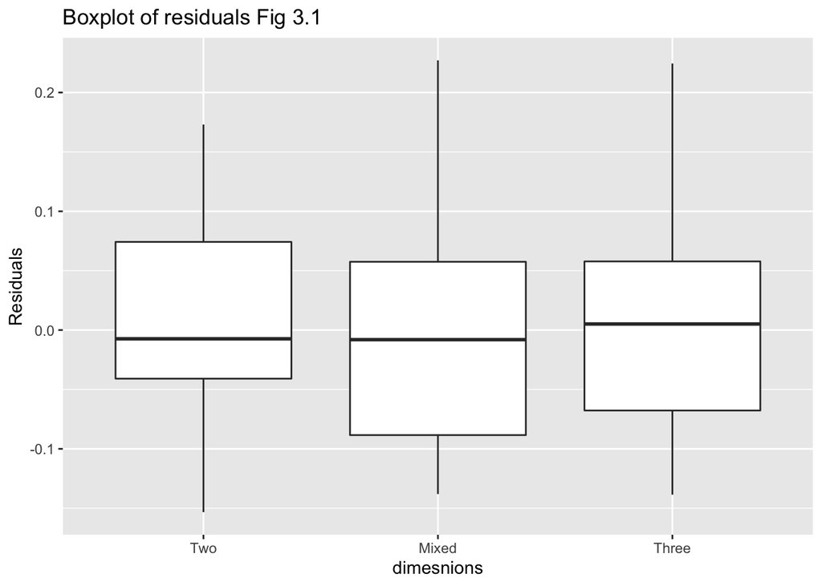

```r
food.web.lm = lm(inv.mean.length ~ 0 + dimension,data = food.web)
food.web$resu = residuals(food.web.lm)
ggplot(food.web, aes(x = dimension, y = resu)) + geom_boxplot() + ggtitle("Boxplot of residuals Fig 3.1") + xlab("dimesnions") + ylab("Residuals")
```

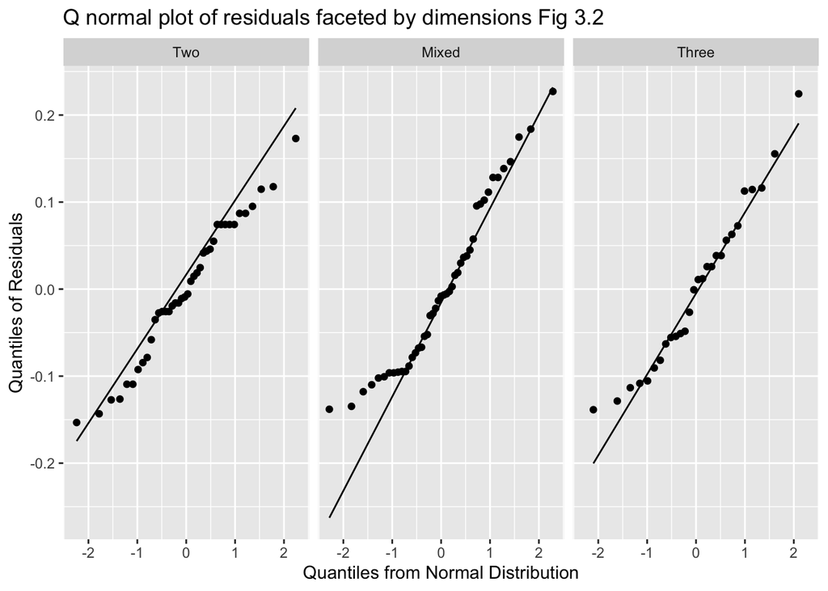

```r
ggplot(food.web, aes(sample = resu)) + stat_qq() + stat_qq_line() + facet_wrap(~dimension) + ggtitle("Q normal plot of residuals faceted by dimensions Fig 3.2") + xlab("Quantiles from Normal Distribution") + ylab("Quantiles of Residuals")
```

```r
summary(food.web.lm)
```

```
##
## Call:
## lm(formula = inv.mean.length ~ 0 + dimension, data = food.web)
##
## Residuals:
##       Min        1Q    Median        3Q       Max
## -0.153296 -0.078453 -0.006745  0.062865  0.227094
##
## Coefficients:
##                Estimate Std. Error t value Pr(>|t|)
## dimensionTwo    0.42578    0.01421   29.96   <2e-16 ***
## dimensionMixed  0.37171    0.01340   27.75   <2e-16 ***
## dimensionThree  0.30751    0.01698   18.11   <2e-16 ***
## ---
## Signif. codes:  0 '***' 0.001 '**' 0.01 '*' 0.05 '.' 0.1 ' ' 1
##
## Residual standard error: 0.08987 on 110 degrees of freedom
## Multiple R-squared:  0.9478, Adjusted R-squared:  0.9463
## F-statistic: 665.1 on 3 and 110 DF,  p-value: < 2.2e-16
```

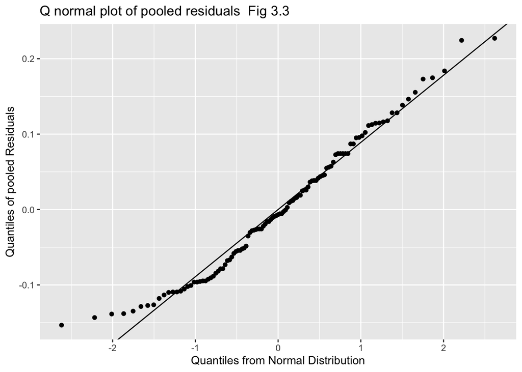

```r
ggplot(food.web, aes(sample = resu)) + stat_qq() + geom_abline(intercept = 0, slope = sd(food.web$resu)) + ggtitle("Q normal plot of pooled residuals  Fig 3.3") + xlab("Quantiles from Normal Distribution") + ylab("Quantiles of pooled Residuals")
```

The r-squared error is 0.94 and it shows that the dependency is good and from graph Fig 3.3 of the q normal plot of poolef residuals is normally distributed.